# Hard Work 3 Part 2

## Instructions

1. Study Sections 3.9-3.11 of Chapter 3: “Diagnostics and Remedial Measures.”
2. Attempt and submit at least {27} Hard Work Points by Saturday at 11:59 PM.  
   Over {37} gets you {+1} Final Exam Point.

## Reading Points {18} Possible

### Section 3.9 {7}{ 7 / 7 }

### Section 3.10 {4}{ 4 / 4 }

### Section 3.11 {7}{ 7 / 7 }

## Theory Points {7} Possible

### Exercise 3.20 {3}{ 3 / 3 }

If the error terms in a regression model are independent $N(0,\sigma^{2})$, what can be said about the error terms after transformation $X^{\prime} = 1/X$ is used? Is the situation the same after transformation $Y^{\prime} = 1/Y$ is used?

**Solution:**

The error terms would not change after a transformation on the X variable because transformations on the X variable are meant to fix linearity problems while keeping variance constant. While the transformation on the Y variable is meant to fix constant variance problems.

### Exercise 3.22 {4}{ 4 / 4 }

Using (A.70), (A.41), and (A.42), show that $E[MSPE] = \sigma^{2}$ for normal error regression model (2.1).

**Solution:**

$$\begin{align*}
E[MSPE] &= E\left[\dfrac{\Sigma\Sigma\left(Y_{ij}-\bar{Y_{j}}\right)^{2}}{n-c}\right] \\
&= \dfrac{1}{n-c}\Sigma E[(n_{j} - 1)s^{2}_{j}] \\
&= \dfrac{1}{n-c}\Sigma E[\sigma^{2}\chi^{2}(n_{j}-1)] \\
&= \dfrac{\sigma^{2}}{n-c}\Sigma(n_{j}-1) \\
&= \sigma^{2}
\end{align*}$$

## Application Points {17} Possible

[Data Files](http://www.stat.ufl.edu/~rrandles/sta4210/Rclassnotes/data/textdatasets/index.html)

### Problem 3.16 {6}{ 6 / 6 }

```r
# Load the Data:
p3.15 <- read.table("http://www.stat.ufl.edu/~rrandles/sta4210/Rclassnotes/data/textdatasets/KutnerData/Chapter%20%203%20Data%20Sets/CH03PR15.txt")

# Rewrite the column names to be "Y" and "X" to match the textbook:
colnames(p3.15) <- c("Y","X")

sol.lm <- lm(Y ~ X, p3.15)

scatp <- augment(sol.lm) %>%
  ggplot(aes(x = X, y = Y)) +
  geom_point(shape = 1) +
  labs(title = "Scatter Plot of Data Values") +
  theme_bw()
```

**Refer to Solution Concentration Problem 3.15**

**a)** Prepare a scatter plot of the data. What transformation of Y might you try, using the prototype patterns in Figure 3.15 to achieve constant variance and linearity?

**Solution:**

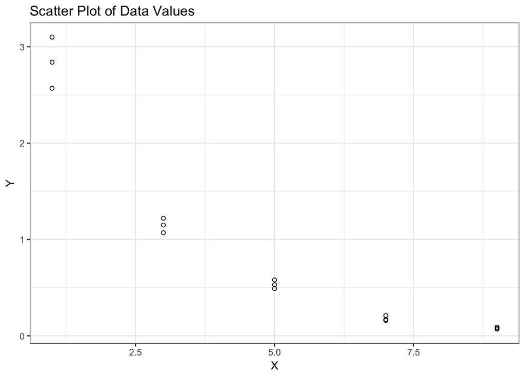

```r
scatp
```

It looks like there is a linearity issue and variance issue. So I would probably do a transformation on both the Y and X variables. For $Y$, I would use $Y^{\prime} = \log_{10} Y$. And for $X$ I would use $X^{\prime} = 1/x.$

**b)** Use the Box-Cox procedure and standardization (3.36) to find an appropriate power transformation. Evaluate SSE for $\lambda = -.2,-.1,0,.1,.2$. What transformation of Y is suggested?

**Solution:**

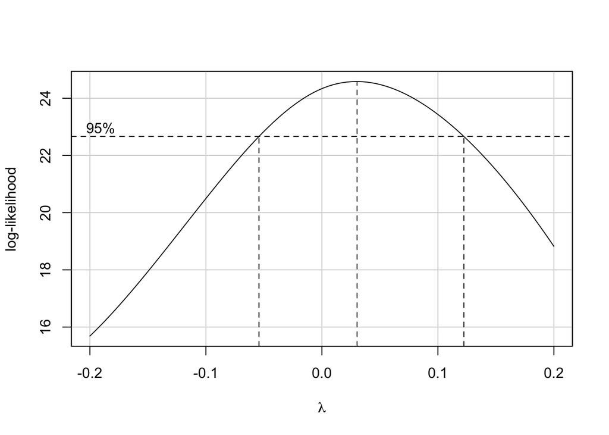

```r
boxCox(sol.lm, lambda = seq(-.2,.2,.1))
```

**c)** Use the transformation $Y^{\prime} = \log_{10} Y$ and obtain the estimated linear regression function for the transformed data.

**Solution:**

```r
sol.log.lm <- lm(log10(Y) ~ X, p3.15)
summary(sol.log.lm)
```

```
##
## Call:
## lm(formula = log10(Y) ~ X, data = p3.15)
##
## Residuals:
##       Min        1Q    Median        3Q       Max
## -0.082958 -0.044421  0.006813  0.033512  0.085550
##
## Coefficients:
##              Estimate Std. Error t value Pr(>|t|)
## (Intercept)  0.654880   0.026181   25.01 2.22e-12 ***
## X           -0.195400   0.004557  -42.88 2.19e-15 ***
## ---
## Signif. codes:  0 '***' 0.001 '**' 0.01 '*' 0.05 '.' 0.1 ' ' 1
##
## Residual standard error: 0.04992 on 13 degrees of freedom
## Multiple R-squared:  0.993,  Adjusted R-squared:  0.9924
## F-statistic:  1838 on 1 and 13 DF,  p-value: 2.188e-15
```

$$\log_{10}{Y_{i}} = \hat{Y_{i}}^{\prime} = b_{0} + b_{1}X_{i} \\
\log_{10}{Y_{i}} = \hat{Y_{i}}^{\prime} = 0.6548798 + -0.1954003X_{i}$$

**d)** Plot the estimated regression line and the transformed data. Does the regression line appear to be a good fit to the transformed data?

**Solution:**

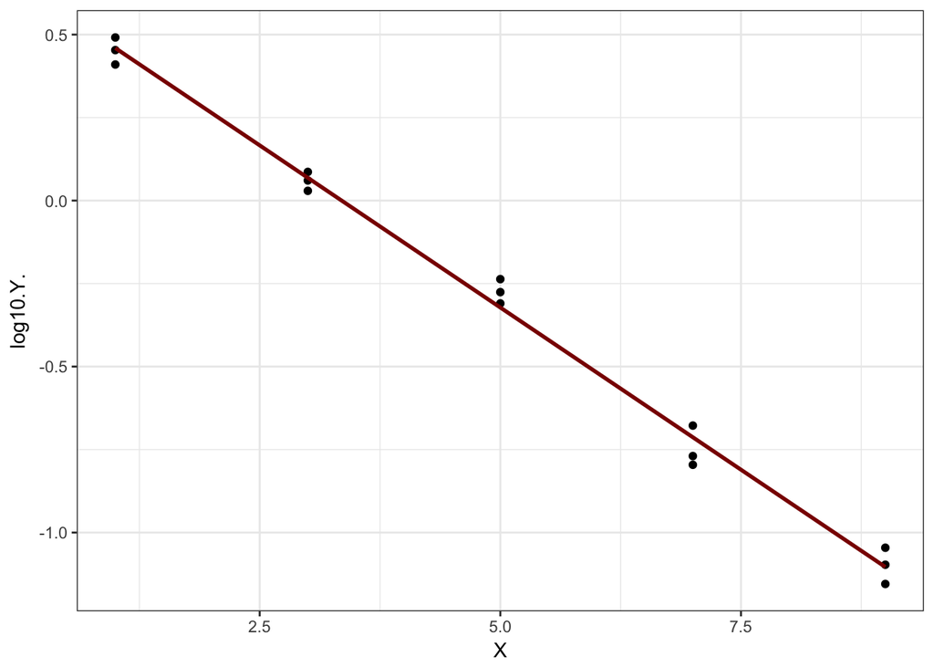

```r
augment(sol.log.lm) %>%
  ggplot(aes(x = X, y = log10.Y.)) +
  geom_point() +
  geom_smooth(method="lm", se = FALSE, color = "darkred") +
  theme_bw()
```

It looks better but there are still some variance issues.

**e)** Obtain the residuals and plot them against the fitted values. Also prepare a normal probability plot. What do your plots show?

**Solution:**

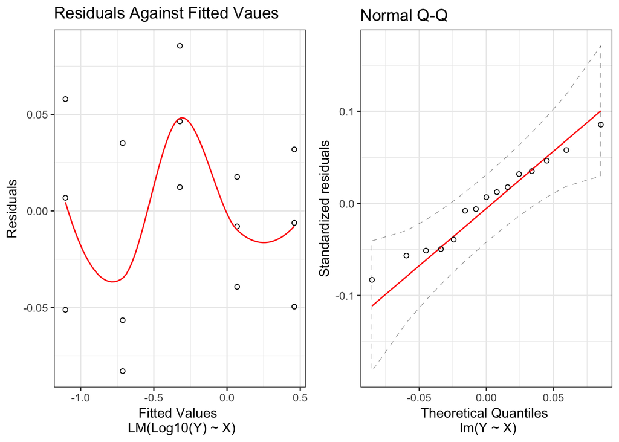

```r
fitted.resid <- augment(sol.log.lm) %>%
  ggplot(aes(x = .fitted, y = .resid)) +
  geom_point(shape = 1) +
  geom_smooth(method="loess", se=FALSE, color="red", size = .5) +
  labs(title = "Residuals Against Fitted Vaues",
       x = "Fitted Values \n LM(Log10(Y) ~ X)", y = "Residuals") +
  theme_bw()

qq.norm <- augment(sol.log.lm) %>%
  ggplot(aes(sample = .resid)) +
  stat_qq_band(color = "black", fill = NA, linetype = 2) +
  stat_qq_line(color = "red", size = .5) +
  stat_qq_point(shape = 1) +
  labs(title = "Normal Q-Q",
       x = "Theoretical Quantiles \n lm(Y ~ X)",
       y = "Standardized residuals") +
  theme_bw()

fitted.resid + qq.norm
```

**f)** Express the estimated regression function in the original units.

**Solution:**

$$\hat{Y_{i}} = 10^{(b_{0}+b_{1}X_{i})} \\
\hat{Y_{i}} = 10^{(0.6548798 + -0.1954003X_{i})}$$

### Problem 3.17 {6}{ 6 / 6 }

```r
# Load the Data:
p3.17 <- read.table("http://www.stat.ufl.edu/~rrandles/sta4210/Rclassnotes/data/textdatasets/KutnerData/Chapter%20%203%20Data%20Sets/CH03PR17.txt")

# Rewrite the column names to be "Y" and "X" to match the textbook:
colnames(p3.17) <- c("Y","X")

sales.lm <- lm(Y ~ X, p3.17)

scatp <- augment(sales.lm) %>%
  ggplot(aes(x = X, y = Y)) +
  geom_point(shape = 1) +
  labs(title = "Scatter Plot of Data") +
  theme_bw()
```

**Sales Growth. A marketing researcher studied annual sales of a product that had been introduced 10 years ago. The data are as follows, where X is the year (coded) and Y is sales in thousands.**

**a)** Prepare a scatter plot of the data. Does a linear relation appear adequate here?

**Solution:**

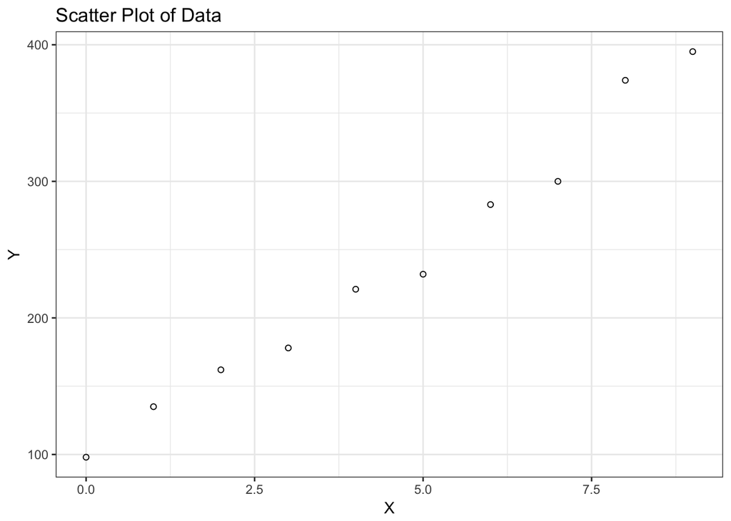

```r
scatp
```

Yes, these data appear to have a linear relationship.

**b)** Use the Box-Cox procedure and standardization (3.36) to find an appropriate power transformation of Y. Evaluate SSE for $\lambda = .3,.4,.5,.6,.7$. What transformation of Y is suggested?

**Solution:**

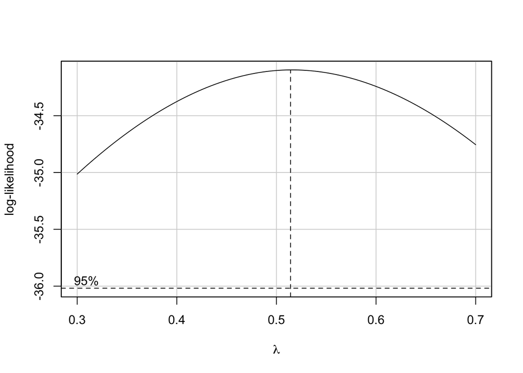

```r
boxCox(sales.lm, lambda = seq(.3,.7,.1))
```

It would probably be best to assign $\lambda = 0.5$

**c)** Use the transformation $Y^{\prime} = \sqrt{Y}$ and obtain the estimated linear regression function for the transformed data.

**Solution:**

```r
sales.sqrt.lm <- lm(sqrt(Y) ~ X, p3.17)
summary(sales.sqrt.lm)
```

```
##
## Call:
## lm(formula = sqrt(Y) ~ X, data = p3.17)
##
## Residuals:
##      Min       1Q   Median       3Q      Max
## -0.47447 -0.30811  0.01549  0.29541  0.46781
##
## Coefficients:
##             Estimate Std. Error t value Pr(>|t|)
## (Intercept) 10.26093    0.21290   48.20 3.80e-11 ***
## X            1.07629    0.03988   26.99 3.83e-09 ***
## ---
## Signif. codes:  0 '***' 0.001 '**' 0.01 '*' 0.05 '.' 0.1 ' ' 1
##
## Residual standard error: 0.3622 on 8 degrees of freedom
## Multiple R-squared:  0.9891, Adjusted R-squared:  0.9878
## F-statistic: 728.4 on 1 and 8 DF,  p-value: 3.826e-09
```

$$\sqrt{Y_{i}} = \hat{Y_{i}}^{\prime} = b_0 + b_1X_i \\
\sqrt{Y_{i}} = \hat{Y_{i}}^{\prime} = 10.2609315 + 1.0762918X_i$$

**d)** Plot the estimated regression line and the transformed data. Does the regression line appear to be a good fit to the transformed data?

**Solution:**

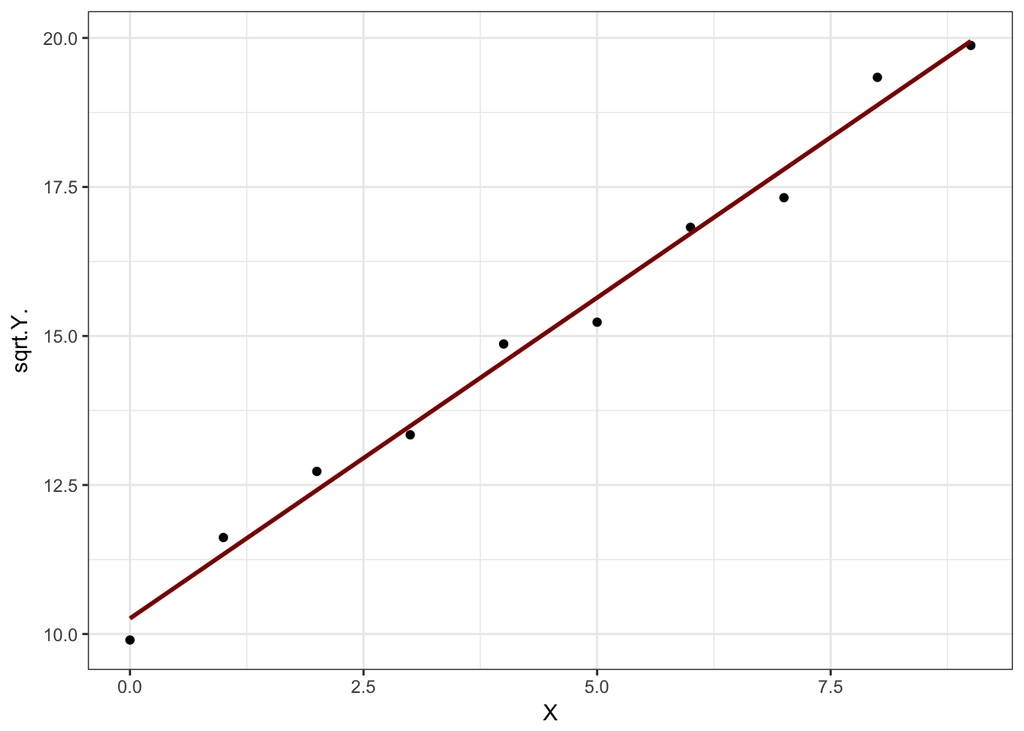

```r
augment(sales.sqrt.lm) %>%
  ggplot(aes(x = X, y = sqrt.Y.)) +
  geom_point() +
  geom_smooth(method="lm", se = FALSE, color = "darkred") +
  theme_bw()
```

Yes, it appears to fit well to these data.

**e)** Obtain the the residuals plot and plot them against the fitted values. Also prepare a normal probability plot. What do your plots show?

**Solution:**

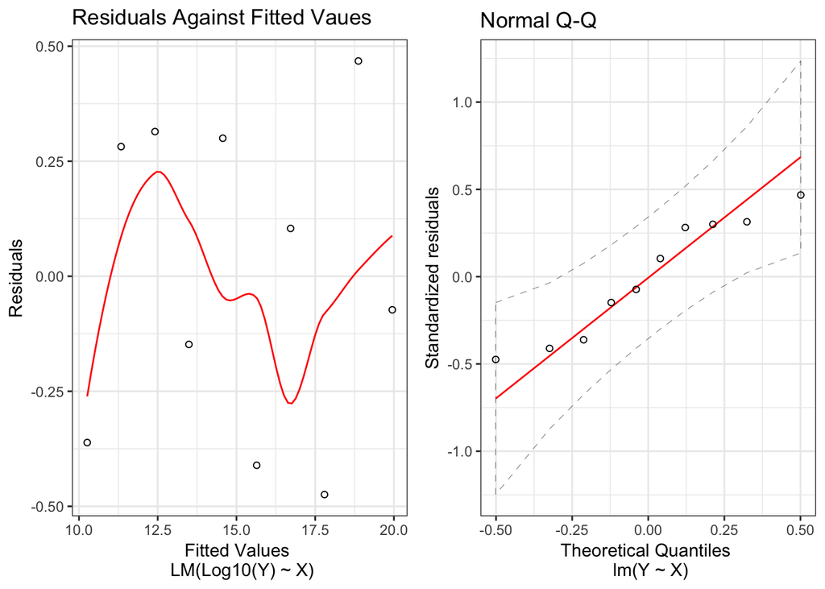

```r
fitted.resid <- augment(sales.sqrt.lm) %>%
  ggplot(aes(x = .fitted, y = .resid)) +
  geom_point(shape = 1) +
  geom_smooth(method="loess", se=FALSE, color="red", size = .5) +
  labs(title = "Residuals Against Fitted Vaues",
       x = "Fitted Values \n LM(Log10(Y) ~ X)", y = "Residuals") +
  theme_bw()

qq.norm <- augment(sales.sqrt.lm) %>%
  ggplot(aes(sample = .resid)) +
  stat_qq_band(color = "black", fill = NA, linetype = 2) +
  stat_qq_line(color = "red", size = .5) +
  stat_qq_point(shape = 1) +
  labs(title = "Normal Q-Q",
       x = "Theoretical Quantiles \n lm(Y ~ X)",
       y = "Standardized residuals") +
  theme_bw()

fitted.resid + qq.norm
```

It shows that the residuals exhibit non-linearity and non-constant variance but the residuals are normally distributed.

**f)** Express the estimated regression function in the original units.

**Solution:**

$$\hat{Y_{i}} = (10.2609315 + 1.0762918X_i)^{2}$$

### Problem 3.18 {5}{ 5 / 5 }

```r
# Load the Data:
p3.18 <- read.table("http://www.stat.ufl.edu/~rrandles/sta4210/Rclassnotes/data/textdatasets/KutnerData/Chapter%20%203%20Data%20Sets/CH03PR18.txt")

# Rewrite the column names to be "Y" and "X" to match the textbook:
colnames(p3.18) <- c("Y","X")

prod.lm <- lm(Y ~ X, p3.18)

scatp <- augment(prod.lm) %>%
  ggplot(aes(x = X, y = Y)) +
  geom_point(shape = 1) +
  labs(title = "Scatter Plot of Data") +
  theme_bw()
```

**Production time. In a manufacturing study, the production times for 111 recent production runs were obtained. The data contains the production time in hours (Y) and the production lot size (X).**

**a)** Prepare a scatter plot of the data. Does a linear relation appear adequate here? Would a transformation on X or Y be more appropriate here? Why?

**Solution:**

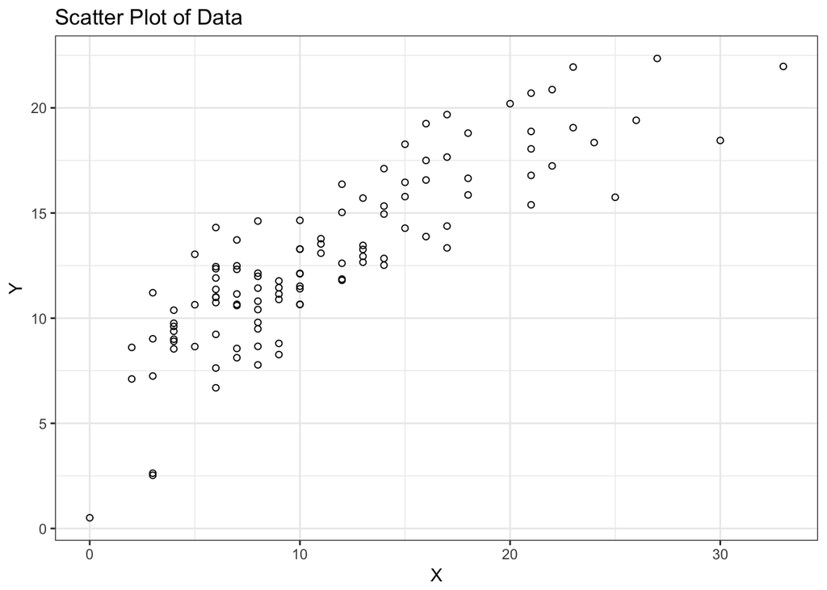

```r
scatp
```

I would use the transformation $X^{\prime} = \sqrt{X}$

**b)** Use the transformation $X^{\prime} = \sqrt{X}$ and obtain the estimated linear regression function for the transformed data.

**Solution:**

```r
prod.sqrt.lm <- lm(Y ~ I(sqrt(X)), p3.18)
summary(prod.sqrt.lm)
```

```
##
## Call:
## lm(formula = Y ~ I(sqrt(X)), data = p3.18)
##
## Residuals:
##     Min      1Q  Median      3Q     Max
## -5.0008 -1.2161  0.0383  1.3367  4.1795
##
## Coefficients:
##             Estimate Std. Error t value Pr(>|t|)
## (Intercept)   1.2547     0.6389   1.964   0.0521 .
## I(sqrt(X))    3.6235     0.1895  19.124   <2e-16 ***
## ---
## Signif. codes:  0 '***' 0.001 '**' 0.01 '*' 0.05 '.' 0.1 ' ' 1
##
## Residual standard error: 1.99 on 109 degrees of freedom
## Multiple R-squared:  0.7704, Adjusted R-squared:  0.7683
## F-statistic: 365.7 on 1 and 109 DF,  p-value: < 2.2e-16
```

$$\hat{Y_{i}} = 1.2546966 + 3.6235203\sqrt{X_{i}}$$

**c)** Plot the estimated regression line and the transformed data. Does the regression line appear to be a good fit to the transformed data?

**Solution:**

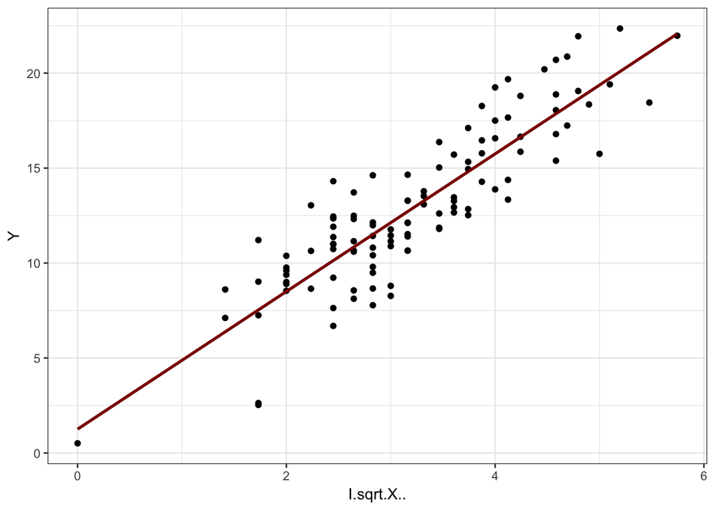

```r
augment(prod.sqrt.lm) %>%
  ggplot(aes(x = I.sqrt.X.., y = Y)) +
  geom_point() +
  geom_smooth(method = "lm", se = FALSE, color = "darkred") +
  theme_bw()
```

Yes it looks like a good fit.

**d)** Obtain the residuals and plot them against the fitted values. Also prepare a normal probability plot. What do your plots show?

**Solution:**

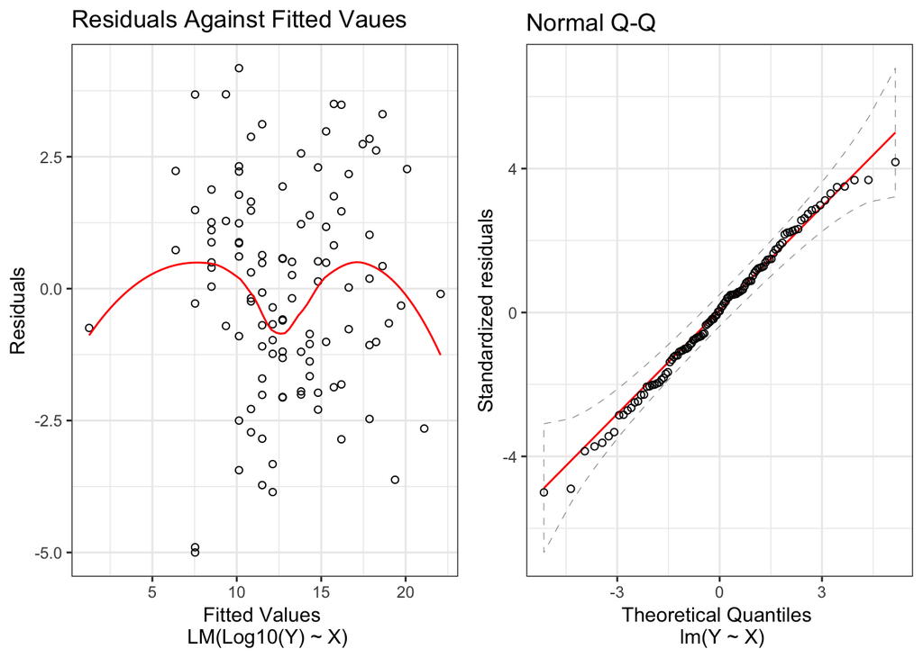

```r
fitted.resid <- augment(prod.sqrt.lm) %>%
  ggplot(aes(x = .fitted, y = .resid)) +
  geom_point(shape = 1) +
  geom_smooth(method="loess", se=FALSE, color="red", size = .5) +
  labs(title = "Residuals Against Fitted Vaues",
       x = "Fitted Values \n LM(Log10(Y) ~ X)", y = "Residuals") +
  theme_bw()

qq.norm <- augment(prod.sqrt.lm) %>%
  ggplot(aes(sample = .resid)) +
  stat_qq_band(color = "black", fill = NA, linetype = 2) +
  stat_qq_line(color = "red", size = .5) +
  stat_qq_point(shape = 1) +
  labs(title = "Normal Q-Q",
       x = "Theoretical Quantiles \n lm(Y ~ X)",
       y = "Standardized residuals") +
  theme_bw()

fitted.resid + qq.norm
```

**e)** Express the estimated regression function in the original units.

**Solution:**